# Introduction to raster datasets

RaumAn4

How we can import a raster dataset using R

Patrick Laube , Nils Ratnaweera , Nikolaos Bakogiannis  
12-07-2021

One of the important aspects of the upcoming exercise (Multi-Criteria Evaluation (MCE)) is the use and manipulation of **raster datasets**. In `R`, two are the main packages used to handle raster data: `terra` and `raster` package. The latter is still heavily used, but inevitably is going to be replaced by the first one.

Below we will use `terra` to demonstrate how we can import a raster dataset. In the link below you can download a tif file, representing the `Digital Elevation Model` *(Digitales Höhenmodell, DHM)* of Canton Schwyz in Switzerland. Download the dataset and repeat the code provided.

- dhm25m.tif

```r
library(terra)
```

Import your raster with the function `rast`

```r
dhm_schwyz <- rast("dhm25m.tif")
```

You get some important metadata on the raster dataset when you type the variable name in the console.

```r
dhm_schwyz
```

```
class       : SpatRaster
dimensions  : 1513, 1888, 1  (nrow, ncol, nlyr)
resolution  : 25, 25  (x, y)
extent      : 671937.5, 719137.5, 193512.5, 231337.5  (xmin, xmax, ymin, ymax)
coord. ref. : CH1903 / LV03
source      : dhm25m.tif
name        : dhm25m
```

To get a quick look at the raster dataset, we can simply use either of the following `plot()` function:

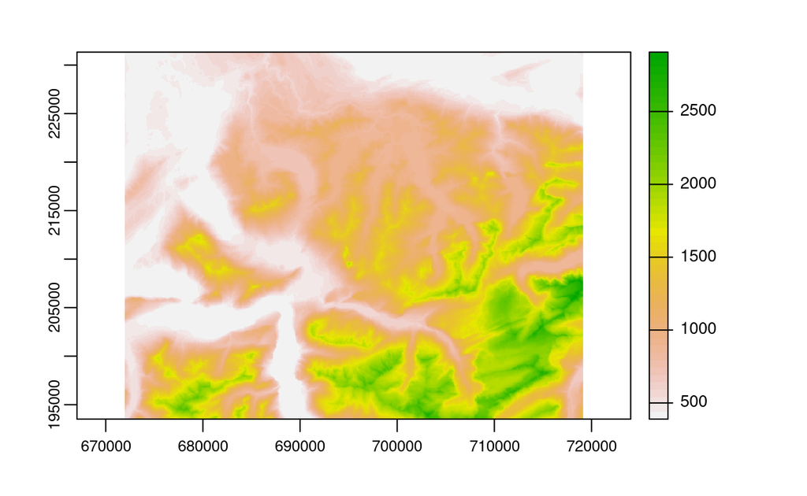

```r
plot(dhm_schwyz)
```

Unfortunately, adding `raster` to ggplot is not very straightforward. Since `ggplot` is a universal plotting framework we quickly reach the limits of what is possible when creating something as specialized as maps. For this reason, we will introduce a new plotting framework which is specialized on maps and was built in a very similar design as ggplot: `tmap`. Install and load this package now.

```r
library(tmap)
```

Just as `ggplot`, `tmap` is based on the idea of “layers” that are joined using a `+`. Each layer has two components:

- a dataset component which is always `tm_shape(dataset)` (replace `dataset` with your variable)
- a geometry component which describes how the preceeding `tm_shape()` should be visualized. This can be `tm_dots()` for points, `tm_polygons()` for polygons, `tm_lines()` for lines etc. For single band raster (which is the case for `dhm_schwyz`), it is `tm_raster()`

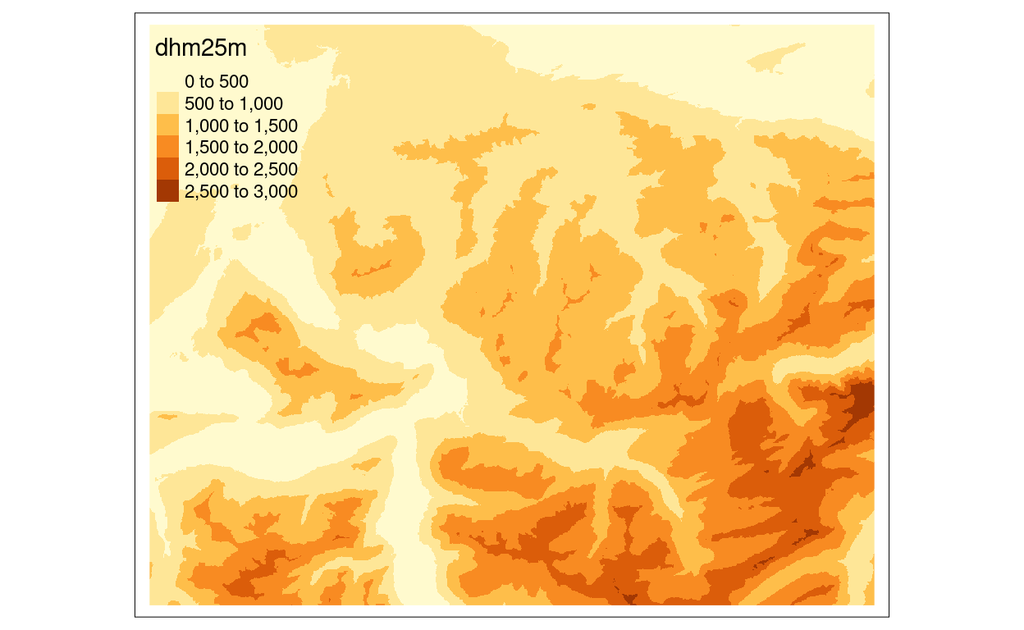

```r
tm_shape(dhm_schwyz) +
  tm_raster()
```

Note that `tm_shape()` and `tm_raster()` (in this case) belong together, one cannot live without the other.

If you consult the help of `?tm_raster` you will see a multitude of options with which to change the visualisation of your data. For example, the default `style` of `tm_raster()` is to create “bins” of the data with a descrete colour scale. We can override this using `style = "cont"`

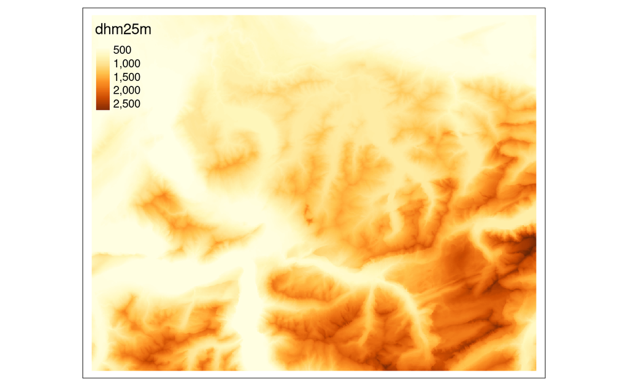

```r
tm_shape(dhm_schwyz) +
  tm_raster(style = "cont")
```

This already looks pretty awesome, but maby we want to change the default colour palette. Fortunately, this is *much* simpler in `tmap` than in `ggplot2`. To look at the available palettes, type `tmaptools::palette_explorer()` or `RColorBrewer::display.brewer.all()` in the console (the former might require you to install additional packages, e.g. `shinyjs`).

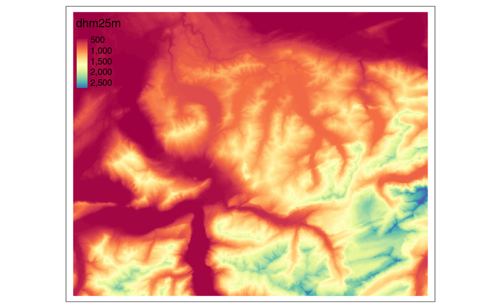

```r
tm_shape(dhm_schwyz) +
  tm_raster(style = "cont", palette = "Spectral")
```

You can make layout adjustments using `tm_layout()`, check `?tm_layout` to see all of the options available!

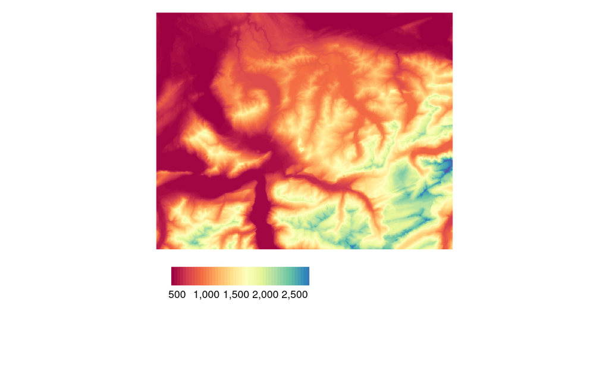

```r
tm_shape(dhm_schwyz) +
  tm_raster(style = "cont", palette = "Spectral", legend.is.portrait = FALSE, title = "") +
  tm_layout(legend.outside = TRUE, legend.outside.position = "bottom",frame = FALSE)
```